Silver Chain  
Data Visualisation

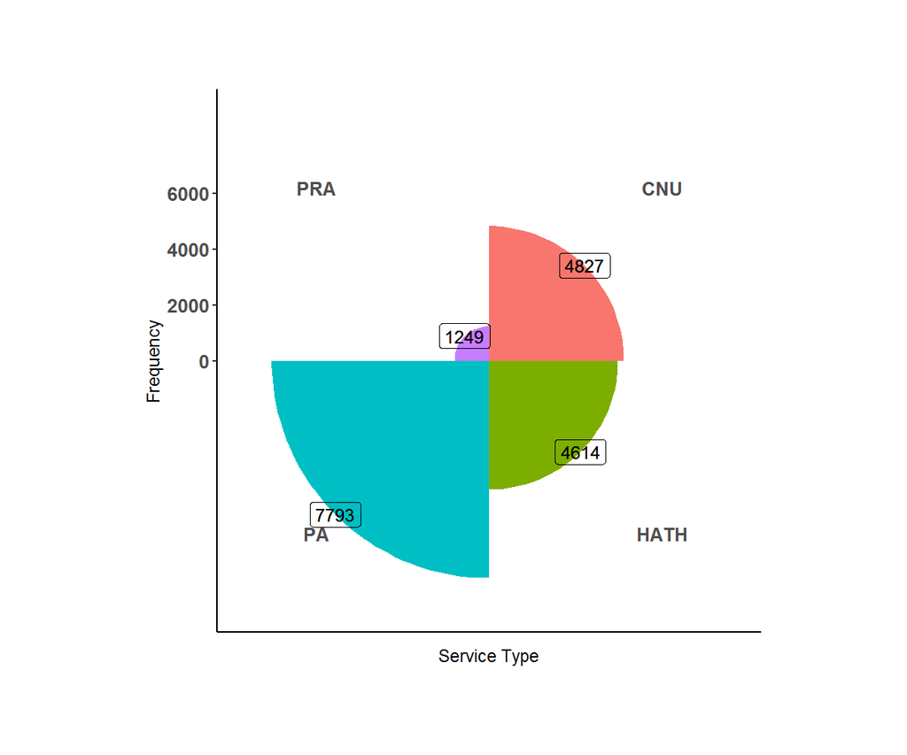

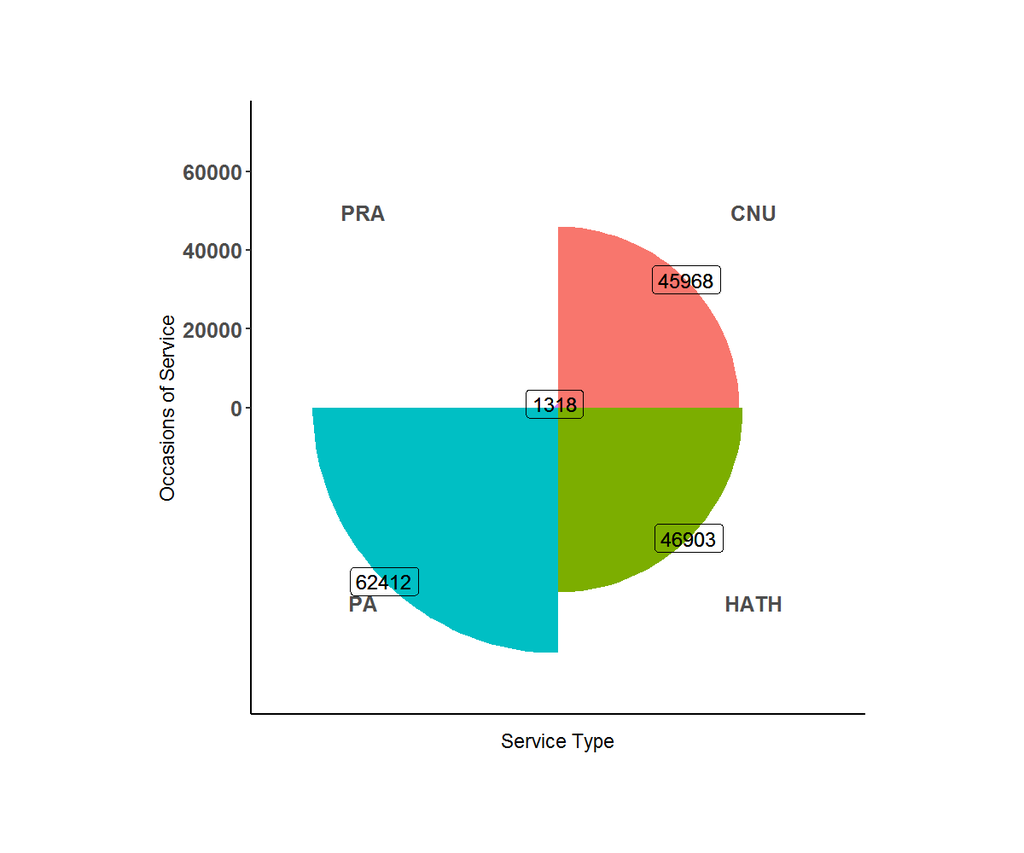

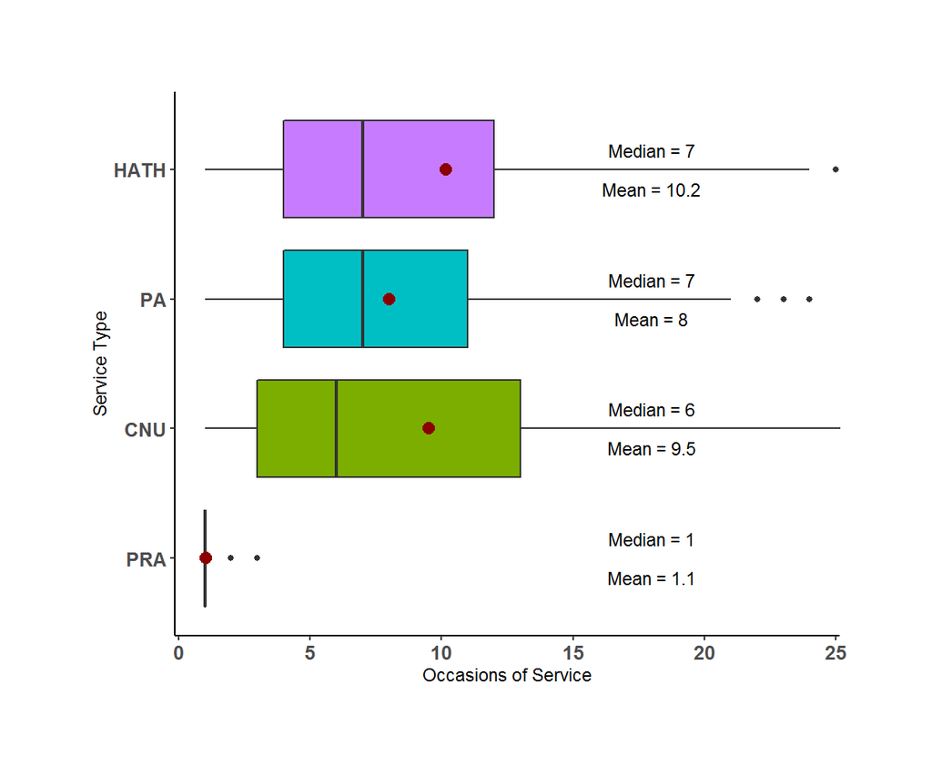

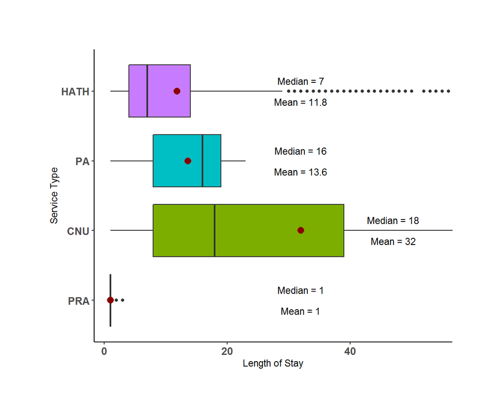

**Coxcomb Plot**  
Number of service episodes by service types

**Coxcomb Plot**  
Number of occasions of service by service types

**Horizontal Box and Whisker Plot**  
Summary statistics on occasions of service by service types

**Horizontal Box and Whisker Plot**  
Summary statistics on length of stay by service types

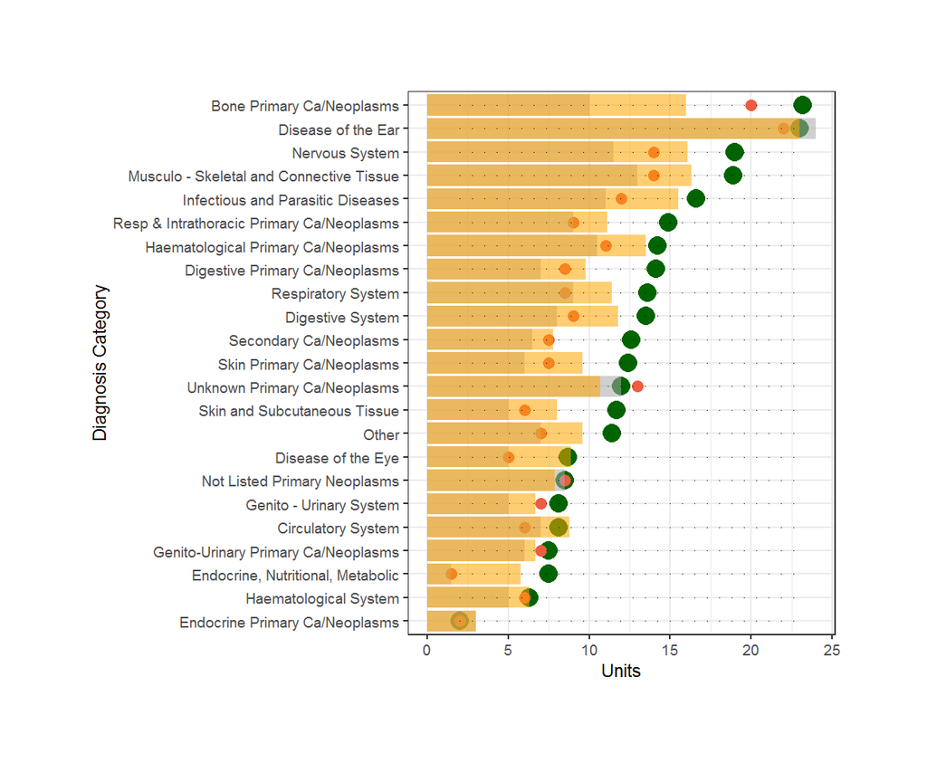

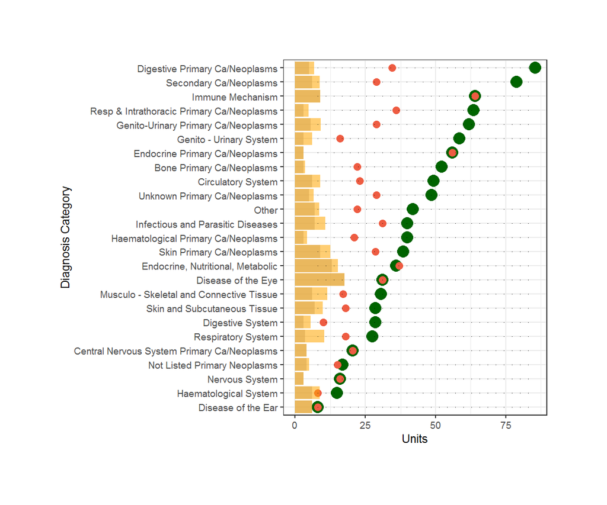

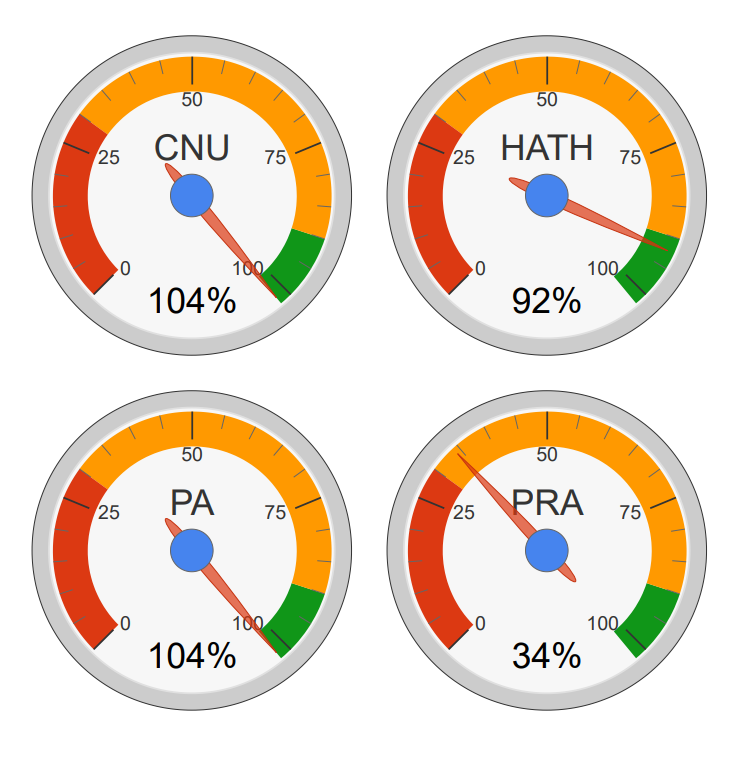

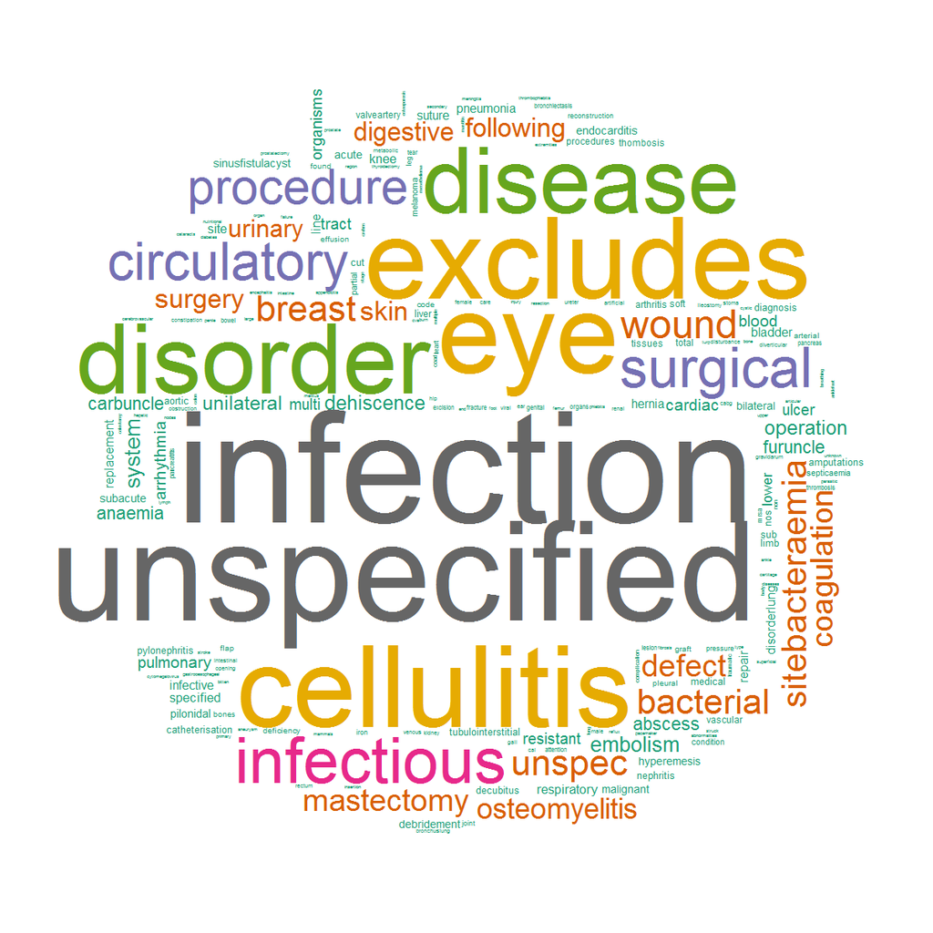

**Horzontal Bar Plot with Representative Points**  
Length of stay and number of eposides  
by diagnosis category for HATH

**Horzontal Bar Plot with Representative Points**  
Length of stay and number of eposides  
by diagnosis category for CNU

**Performance Gauge**  
Volumes (in percentage) for home hospital contract

**Word Cloud Color**  
Basic text analytics (frequency)  
based on natural language processing

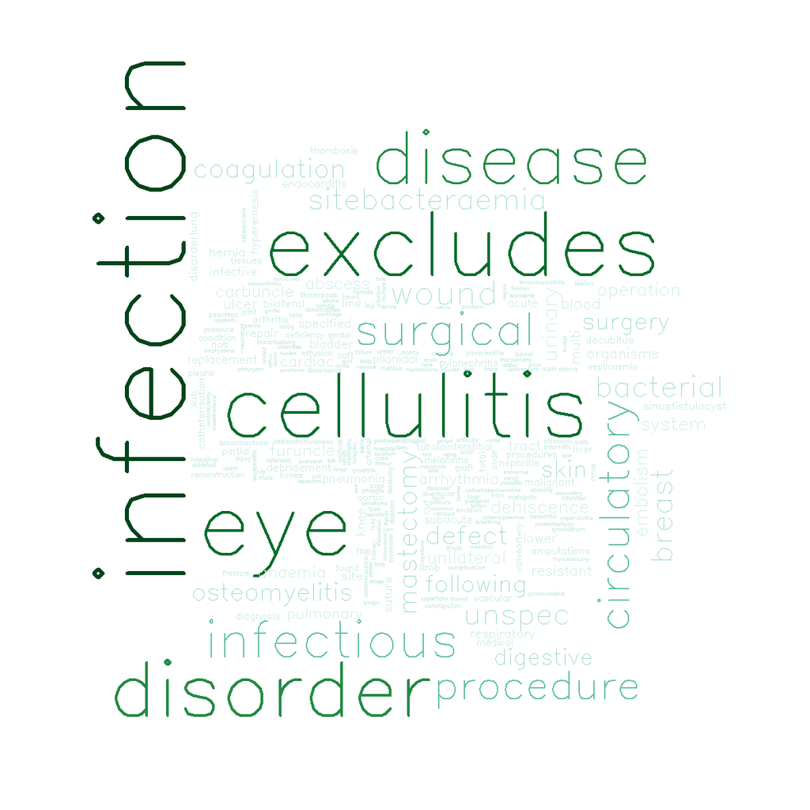

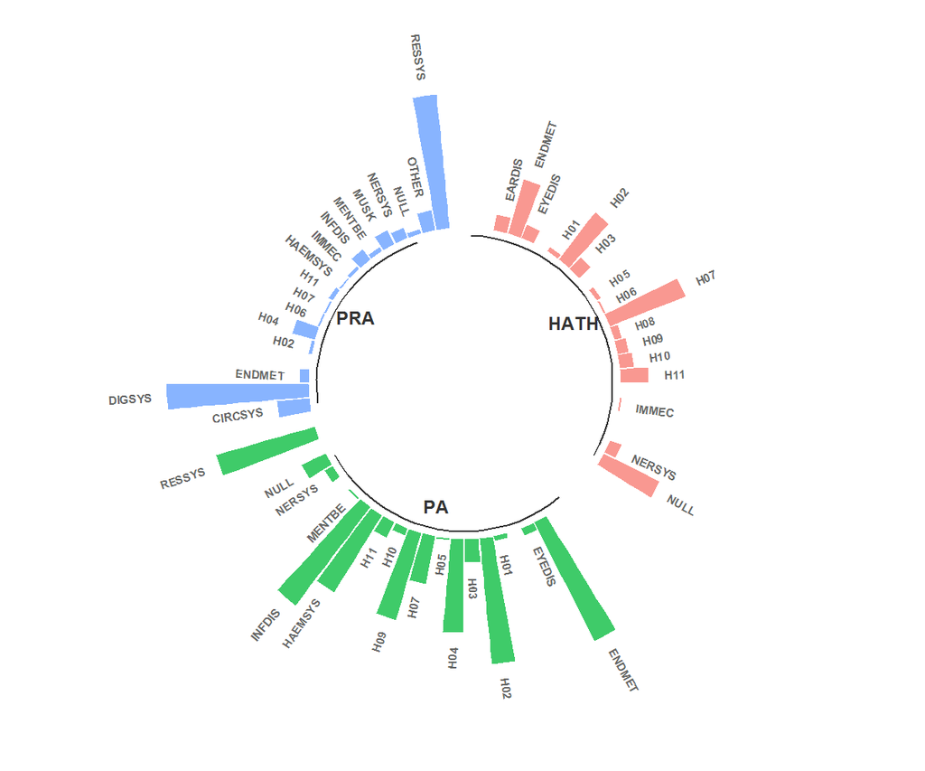

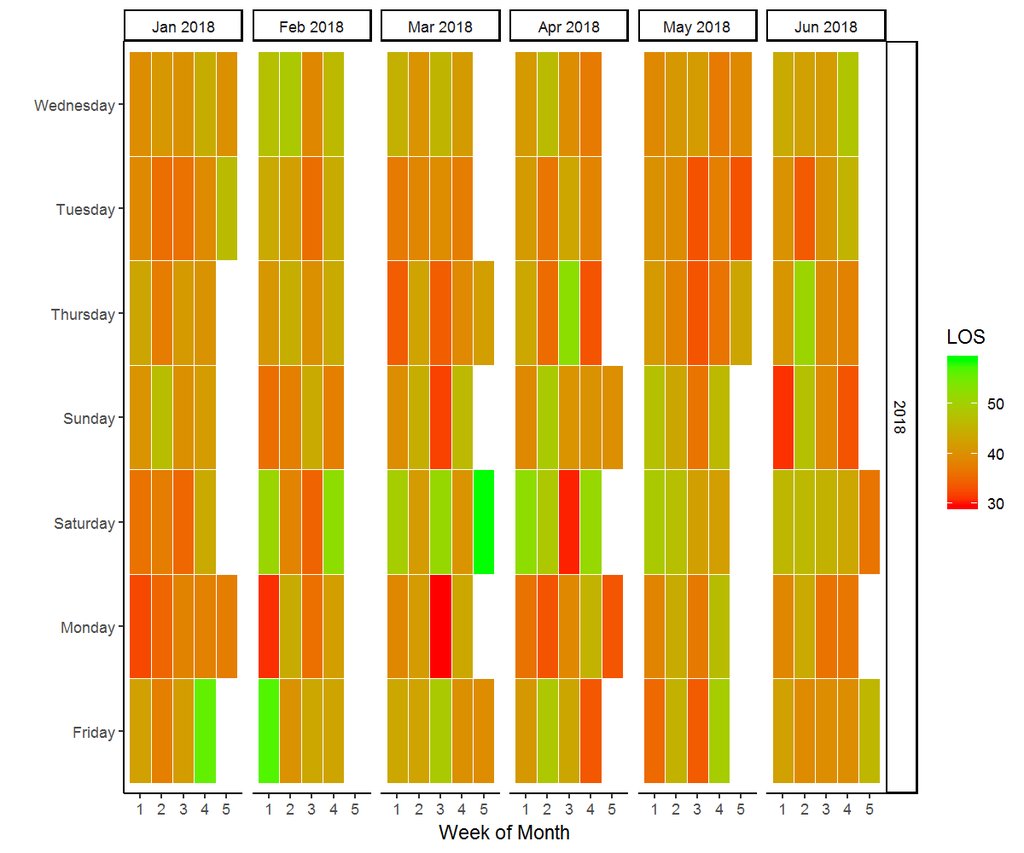

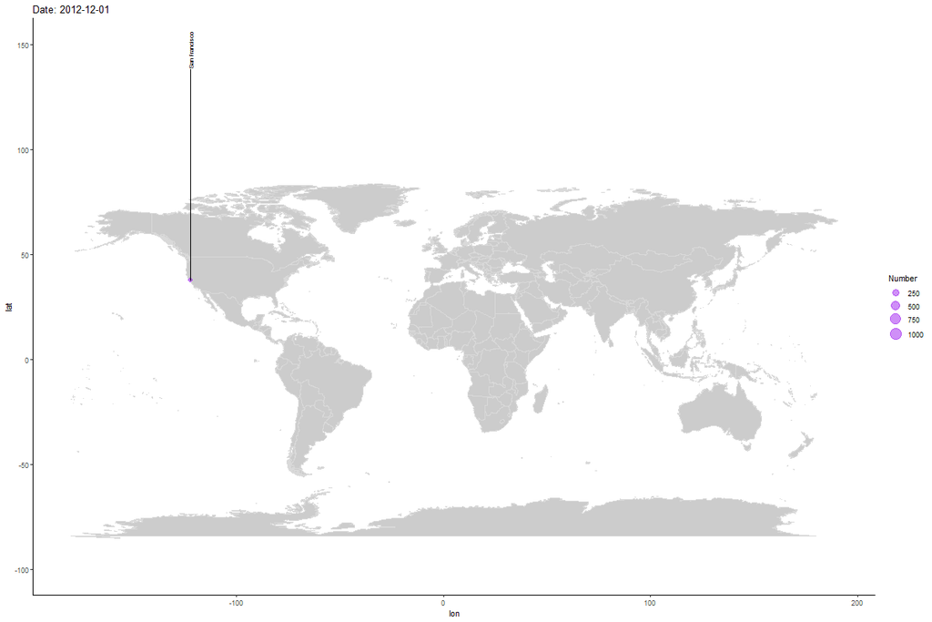

**Word Cloud Plain**  
Basic text analytics (frequency)  
based on natural language processing

**Circular Bar Plot**  
Frequency of service episodes  
by diagnosis category per service type

**Animated Plot**  
World map of twitter feeds animated  
by different time periods

[interactive chart not shown]

**South Australia Metropolitan Heatmap**  
Heatmap based on hospital admission frequency

**Western Australia Clustering Heatmap**  
Heatmap with clustering  
based on western australia service episodes

**Collapsible Interactive Flow Chart**  
Flow chart to visualise patient flow  
with interactive features

[interactive chart not shown]

**Force Diagram**  
An interactive feature to visualise patient flow

**Full Patient Journey**  
Visualise patient’s journey across different time points  
with all activities and indicators presented

**Sankey Plot**  
Patient flow from an interaction point  
to another interaction point